# NFL Losers Pool 2021

Jordan Hutchings

12/10/2021

Our annual NFL losers pool runs by each entrant having to pick one team per week. The objective is to pick one team to lose each week, if your team wins, you are out of the pool. The catch is that once a team is picked it cannot be picked again.

I am taking a fairly simple approach to making my picks this year. Download and use the NFL forecast data from [FiveThirtyEight](https://projects.fivethirtyeight.com/2021-nfl-predictions/games/) to optimize my picks to give the best probability of lasting deep into the season.

```r
source("pick_functions.R")
pacman::p_load(data.table, ggplot2, ggalt, dplyr, knitr, kableExtra)

# Setup ----
path <- "https://projects.fivethirtyeight.com/nfl-api/nfl_elo_latest.csv"
week1 <- as.Date("2021-09-09")
total_weeks <- 10
start_week <- max(ceiling(as.numeric(( Sys.Date() - as.Date("2021-09-09") )) / 7) + 1, 3) # little janky
time_period <- c(start_week:total_weeks)

# past picks ----
past_weeks <- c(1, 2, 3, 4, 5)
past_picks1 <- c("DAL", "TEN", "NYJ", "HOU", "MIA")
past_picks2 <- c("CHI", "TEN", "NYJ", "HOU", "DET")

read_data <- function(path, past_picks, all_weeks = FALSE){
  dt <- data.table::fread(path)

  # calculate week, get proj loser and prob of loss.

  dt[, loser:=ifelse(qbelo_prob1 > qbelo_prob2, team2, team1)]
  dt[, winner:=ifelse(qbelo_prob1 > qbelo_prob2, team1, team2)]
  dt[, p_win:=ifelse(qbelo_prob1 > qbelo_prob2, qbelo_prob2, qbelo_prob1)]
  dt[, p_win_winner:=ifelse(qbelo_prob1 > qbelo_prob2, qbelo_prob1, qbelo_prob2)]
  dt[, week:=floor(as.numeric(difftime(date, week1, units="days")) / 7) + 1]

  dt <- dt[, .(week, loser, winner, p_win, p_win_winner)]

  if(!all_weeks){
    dt <- dt[week %in% time_period]
    dt <- dt[!loser %in% past_picks]
  }

  return(dt)
}

df1 <- read_data(path, past_picks1)
df2 <- read_data(path, past_picks2)
```

## Visualizations

Below we can see a heatmap of all the win probabilities throughout the season. Teams like Houston, and Washington have a low likelihood of winning in many games in the season. This motivates our problem as we can only pick them each once. The teams are ordered by average likelihood of winning, we can see Houston, Detroit, and Jacksonville are the three lowest teams. There is an opportunity to out play my competitors by picking these teams in the best possible week, i.e. holding off until Week 4 to pick Houston.

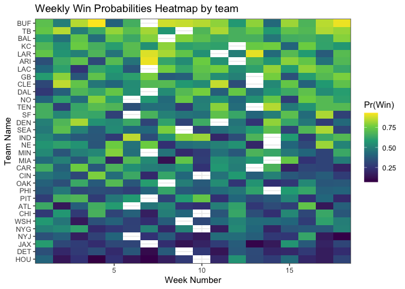

## Historical accuracy of ELO ratings We can plot the average outcome of each historical game bucketing by the probability of each team winning. We can keep only the favourites, as this is the same as looking at 1 - the probability of the underdogs.

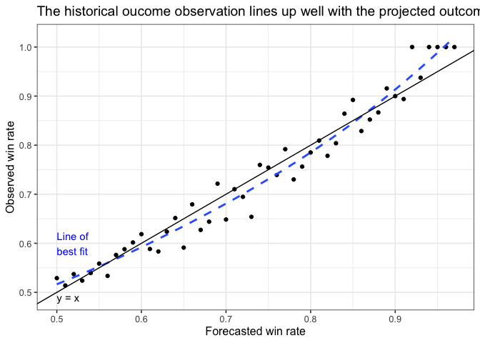

```r
hist_data <- "https://projects.fivethirtyeight.com/nfl-api/nfl_elo.csv"
hdt <- fread(hist_data)

# hdt %>%
#   group_by(season) %>%
#   summarise(sum(is.na(qbelo_prob1))) # begins in 1950

hdt %>%
  mutate(loser_score = ifelse(qbelo_prob1 > qbelo_prob2, score2, score1),
         winner_score = ifelse(qbelo_prob1 > qbelo_prob2, score1, score2),
         p_win_winner = ifelse(qbelo_prob1 > qbelo_prob2, qbelo_prob1, qbelo_prob2),
         win = as.numeric(winner_score > loser_score),
         win_bucket = round(p_win_winner, 2)
         ) %>%
  filter(!is.na(winner_score)) %>%
  # filter(season >= 2000) %>%
  group_by(win_bucket) %>%
  summarise(p = mean(win), n = n(), se = sd(win)) %>%
  ggplot(aes(x = win_bucket, y = p)) +
  geom_point() +
  geom_smooth(alpha = 0.7, linetype = "dashed", se=F) +
  geom_abline(slope = 1) +
  annotate("text", x = 0.5, y = 0.49, label = "y = x", hjust = 0) +
  annotate("text", x = 0.5, y = 0.6, label = "Line of \nbest fit", hjust = 0, color = "blue") +
  labs(title = "The historical oucome observation lines up well with the projected outcomes",
       x = "Forecasted win rate",
       y = "Observed win rate") +
  theme_bw(12)
```

## Optimal picks

```r
make_pick <- function(dt, past_picks, past_weeks, start_week = 3, total_weeks = 13, beta = 1){

  for(i in start_week:total_weeks){

    pick <- dt[week %in% c(start_week:total_weeks)]
    pick <- pick[!loser %in% past_picks & !week %in% past_weeks]
    pick[, value:= p_win * beta^(week - start_week)]
    pick <- pick[order(value)]
    pick <- pick[, .SD[1]]

    past_weeks <- append(past_weeks, pick$week)
    past_picks <- append(past_picks, pick$loser)

  }

  picks <- setDT(data.frame(week = past_weeks, loser = past_picks))
  picks <- merge(picks, dt, on = week)
  picks <- picks[, .(week, loser, p_win)]

  picks
}

path_1 <- make_pick(df1, past_picks1, past_weeks, beta = 1)
path_2 <- make_pick(df2, past_picks2, past_weeks, beta = 1)

tbl <- merge(path_1, path_2, by = "week")
names(tbl) <- c("Week", rep(c("Team", "ProbWin"), 2))

kbl(tbl, digits=3, caption = "Optimal Picks per Week") %>%
  kable_classic(full_width=F) %>%
  add_header_above(c(" " = 1, "First Set of Picks" = 2, "Second Set of Picks" = 2))
```

Optimal Picks per Week

| Week | First Set of Picks Team | First Set of Picks ProbWin | Second Set of Picks Team | Second Set of Picks ProbWin |
| --- | --- | --- | --- | --- |
| 6 | PHI | 0.290 | PHI | 0.290 |
| 7 | DET | 0.107 | CIN | 0.211 |
| 8 | NYG | 0.202 | MIA | 0.124 |
| 9 | JAX | 0.134 | JAX | 0.134 |
| 10 | ATL | 0.229 | ATL | 0.229 |

## Survival Rate

Given the Boolean nature of our predictions, we can compute the likelihood of reaching a given week based on our pick paths.

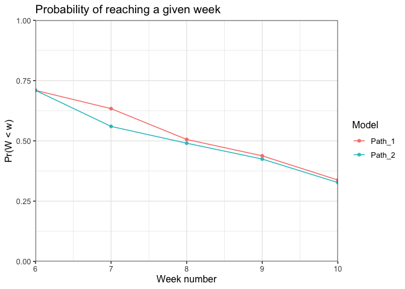

```r
cumprob <- function(picks, inc_weeks = FALSE){
  p <- purrr::accumulate((1-picks$p_win), function(x, y)  x * y)
  weeks <- picks$Week
  if(inc_weeks){ out <- data.frame(p, weeks) }
  else { out <- data.frame(p) }

  out
}

models <- list(path_1, path_2)
results <- lapply(models, function(x) cumprob(x))
results <- do.call(cbind.data.frame, results)
results$week <- seq(start_week, 10, 1)
names(results) <- c("Path_1", "Path_2", "Week")

results %>%
  tidyr::pivot_longer(cols = -Week, names_to = "Model", values_to = "p") %>%
  ggplot(aes(x = Week, y = p, color = Model)) +
  geom_line() +
  geom_point(alpha = 0.8) +
  scale_x_continuous(expand = c(0, 0), limits = c(start_week, 10)) +
  scale_y_continuous(expand = c(0, 0), limits = c(0, 1)) +
  labs(title = "Probability of reaching a given week",
       x = "Week number",
       y = "Pr(W < w)") +
  theme_bw(12)
```

## Comparing the weekly trade-offs between picks

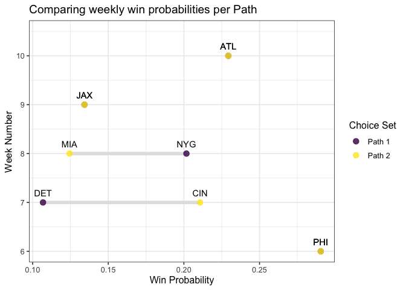

```r
p1 <- path_1
p2 <- path_2
p1$Approach <- "Path 1"
p2$Approach <- "Path 2"
data <- rbind(p1, p2)

ggplot(data, aes(x=week, y=p_win, color = Approach, label = loser)) +
  geom_line(aes(group = week), color="#e3e2e1", size = 2) +
  geom_point(size = 3, alpha = 0.8) +
  geom_text(color = "black", nudge_x = 0.2) +
  xlim(start_week, 10.5) +
  coord_flip() +
  scale_color_viridis_d() +
  labs(title = "Comparing weekly win probabilities per Path",
       x = "Week Number",
       y = "Win Probability",
       color = "Choice Set") +
  theme_bw(12)
```

## Showing the choice set

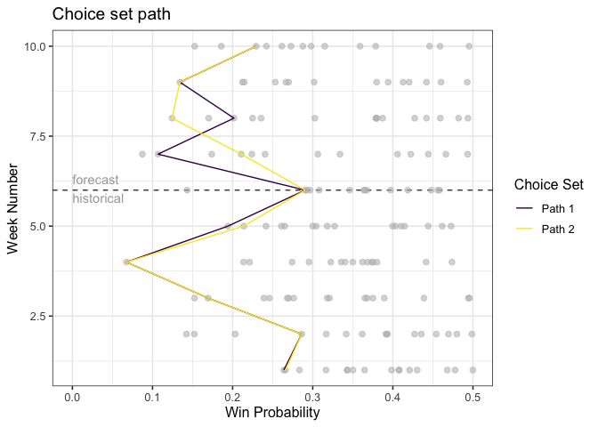

```r
pre1 <- cbind(c(1:(start_week - 1)), past_picks1, "Path 1")
pre2 <- cbind(c(1:(start_week - 1)), past_picks2, "Path 2")
pre <- data.frame(rbind(pre1, pre2))
names(pre) <- c("week", "loser", "Approach")
pre$week <- as.numeric(pre$week)
pre <- left_join(pre, plot_data, by = c("week", "loser"))
pre <- select(pre, c("week", "loser", "p_win", "Approach"))
data <- rbind(pre, data)
data$forecast <- data$week > start_week

ggplot(subset(plot_data, week < 11), aes(x = week, y = p_win)) +
  geom_vline(xintercept = start_week, linetype = "dashed", alpha = 0.8) +
  geom_point(size = 2, color = "grey", alpha = 0.6) +
  geom_line(data = data, mapping = aes(x = week, y = p_win, color = Approach)) +
  coord_flip() +
  xlim(1, 10) +
  annotate("text", x = start_week + 0.05, y = 0, label="forecast \nhistorical", hjust = 0, color = "darkgrey") +
  labs(title = "Choice set path",
       y = "Win Probability",
       x = "Week Number",
       color = "Choice Set") +
  scale_color_viridis_d() +
  theme_bw(12)
```